# SIT 112 - Data Science Concepts - Assignment 1

Lecturer: Truyen Tran | truyen.tran@deakin.edu.au

School of Information Technology,  
Deakin University, VIC 3215, Australia.

### Due: 5pm, Friday 13th April 2018

### Instructions

This notebook has been prepared for you to complete Assignment 1. Some sections have been pre-filled to help you get started. **The total mark for this programming task is 65**.

1. Before you start, read the entire notebook carefully to understand what you need to do. You should also refer to the main instructions in *Assignment1_instructions.pdf* to know what else you need to complete for this assignment.
2. For each cell marked with *#INSERT YOUR CODE HERE*, you must write your own code in this cell.
3. At the end, you must run the entire notebook and submit two files:
   1. The source of your solution notebook: [YourID]_assignment1_solution.ipynb
   2. And an exported version of your output: [YourID]_assignment1_output.html

For example, if your student ID is 123456, then you need submit two files:

1. **123456_assignment1_solution.ipynb**
2. and **123456_assignment1_output.html**

As you go through this notebook:

- markdown cells marked with **Note** mean description sections.
- markdown cells marked with **Instructions** mean the instructions given to you to complete the sections.

```python
"""
Import packages needed for processing
"""
import numpy as np   # import the numpy package
import csv           # this package needed for processing csv file
from collections import Counter  # this is for dictionary construction with counting functionality
import matplotlib.pyplot as plt  # this is for plotting and other descriptive statistics
from datetime import datetime     # this package is for handling time

"""
If you need add any additional packages, then add them below this line
"""
from statistics import median
%matplotlib inline
import re
```

**Note**: you must place your data file in the same folder with your python notebook.

```python
# Declare the path to the data file
DATA_FILE = "medicare-office_locations.csv"
```

**Note**. The following segment of codes is to load the data from the .csv file using csv package. It has been provided for you to get started. Please **do not** change this piece of code as well the variable names as we will need these variables to complete subsequent tasks.

```python
# Load CSV file using DictReader
input_file = csv.DictReader(open(DATA_FILE))
fieldnames = input_file.fieldnames
data_dict = {fn: [] for fn in fieldnames}
print(data_dict.keys())
for line in input_file:
    for k, v in line.items():
        try:
            data_dict[k].append(int(v))
        except ValueError:
            try:
                data_dict[k].append(float(v))
            except ValueError:
                data_dict[k].append(v)

for k, v in data_dict.items():
    data_dict[k] = np.array(v)
```

```
dict_keys(['No.', 'OFFICE TYPE', 'SITE NAME', 'ADDRESS', 'SUBURB', 'STATE', 'POSTCODE', 'LATITUDE', 'LONGITUDE', 'Open', 'Close', 'Closed for lunch'])
```

## **Instruction 1**

We first examine the variables and the overall data size. The tasks:

1. Write your code to print the type for the following variables (**4 marks**):
   - input_file
   - data_dict
   - data_dict['SUBURB']
   - data_dict['STATE']
2. Write your code to print out the number of data records. (**1 mark**)

[**Total mark: 5**]

```python
# INSERT YOUR CODE HERE
'''
1. Write you code to print the type for the following variables:
    * input_file
    * data_dict
    * data_dict['SUBURB']
    * data_dict['STATE']
'''
varList = [input_file, data_dict, data_dict['SUBURB'], data_dict['STATE']]
varNameList = ['input_file', 'data_dict', 'data_dict["SUBURB"]', 'data_dict["STATE"]']



print("List of the variable types:")
print("--------------------------")

j = 0

for i in varList:
    print(varNameList[j] + " is of type " + str(type(i)))
    j += 1
```

```
List of the variable types:
--------------------------
input_file is of type <class 'csv.DictReader'>
data_dict is of type <class 'dict'>
data_dict["SUBURB"] is of type <class 'numpy.ndarray'>
data_dict["STATE"] is of type <class 'numpy.ndarray'>
```

```python
# INSERT YOUR CODE HERE
'''
2. Write your code to print out the number of data records
'''

for key,value in data_dict.items():
        records = len(list(filter(bool, value)))

print("There are " +str(records)+ " records in the CSV")
```

```
There are 239 records in the CSV
```

## Instruction 2

The following code segment is designed to calculate some basic statistics from the data.

**Your task:**

1. Write your code to find and print the minimum and the maximum values in the **LATITUDE** column. (**1 mark**)
2. Write your code to find and print the minimum and maximum values of the **LONGITUDE** column. (**1 marks**)
3. Write your code to find and print the central point of all the locations. This point is a pair of the average of latitudes *(the **LATITUDE** column)* and the average of longitudes *(the **LONGITUDE** column)*. (**3 marks**)

**[Total mark: 5]**

```python
# INSERT YOUR CODE HERE
"""
1. Write your code to find and print the minimum and the maximum values in the **LATITUDE** column.
"""
maxLat = np.max(data_dict['LATITUDE'])
minLat = np.amin(data_dict['LATITUDE'])
print("The maximum latitude value is " + str(maxLat))
print("The minimum latitude value is " + str(minLat))
```

```
The maximum latitude value is -12.37187
The minimum latitude value is -42.97638
```

```python
# INSERT YOUR CODE HERE
"""
2. Write your code to find and print the minimum and maximum values of the **LONGITUDE** column.
"""
maxLong = np.amax(data_dict['LONGITUDE'])
minLong = np.amin(data_dict['LONGITUDE'])
print("The maximum longitude value is " + str(maxLong))
print("The minimum longitude value is " + str(minLong))
```

```
The maximum longitude value is 153.55671
The minimum longitude value is 114.61273
```

```python
# INSERT YOUR CODE HERE
"""
3. Write your code to find and print the central point of all the locations.
This point is a pair of the average of latitudes *(the **LATITUDE** column)*
    and the average of longitudes *(the **LONGITUDE** column)*
"""
avLat = np.average(data_dict['LATITUDE'])
avLong = np.average(data_dict['LONGITUDE'])
print("The central point is at Latitude("+ str(avLat) + ") Longitude(" + str(avLong) +")")
```

```
The central point is at Latitude(-32.4765017992) Longitude(145.580256151)
```

## **Instruction 3**

The following code segment is designed to examine data from the **STATE** column. This column provides information about the states of medical centers.

**Your tasks**:

1. Write your code to find and print out the number of **unique** states. (**3 marks**)
2. Write your code to find and print out the list of states that appears more than **ten** times in the dataset. (**3 marks**)
3. Write your code to find and print out the state with highest frequency. Both the state name and frequency need to be printed out (**3 marks**)
4. Write your code to construct a dictionary variable: *state_popularity* whose keys are unique states and values are the corresponding counts computed from the dataset. Print the dictionary. (**3 marks**)
5. Plot a bar chart for *state_popularity* sorted in descending order of values. (**3 marks**)

[**Total mark: 15**]

```python
# INSERT YOUR CODE HERE
"""
1. Write your code to find and print out the number of **unique** states.
Hint: you might want to use np.unique
"""
#get unique state names
uniqueStates = np.unique(data_dict['STATE'])
print("There are " +str(len(uniqueStates))+ " unique states")
```

```
There are 8 unique states
```

```python
# INSERT YOUR CODE HERE
"""
2. Write your code to find and print out the list of states
    that appears more than **ten** times in the dataset.

Hint: read the documention for function numpy.unique carefully and examine what does it return.
"""
#put state column into np array
stateArray = np.array(data_dict["STATE"])
print("States with more than 10 locations")
print("----------------------------------")

for i in uniqueStates:
    #check if the number of times a state appears is more than 10
    count = (stateArray == i).sum()
    if count > 10:
        print("There are " +str(count)+ " locations in " + str(i))
```

```
States with more than 10 locations
----------------------------------
There are 87 locations in NSW
There are 49 locations in QLD
There are 14 locations in SA
There are 54 locations in VIC
There are 19 locations in WA
```

```python
# INSERT YOUR CODE HERE
"""
3. Write your code to find and print out the state with highest frequency.
Both the state name and frequency need to be printed out
"""
maxFrequency = 0
stateName = None
for i in uniqueStates:
    #sum up frequency of state name occurrence
    count = (stateArray == i).sum()
    #find highest value
    if count > maxFrequency:
        maxFrequency = count
        stateName = i
print(str(stateName) + " has the highest frequency with " + str(maxFrequency) + " locations")
```

```
NSW has the highest frequency with 87 locations
```

```python
# INSERT YOUR CODE HERE
"""
4. Write your code to construct a dictionary variable: ***state_popularity***
    whose keys are unique states and values are the corresponding counts computed from the dataset.
Print the dictionary.
"""
#put stateArray in counter() format
state_popularity = Counter(stateArray)

for state, count in state_popularity.most_common():
    print(state, count)
```

```
NSW 87
VIC 54
QLD 49
WA 19
SA 14
TAS 7
ACT 5
NT 4
```

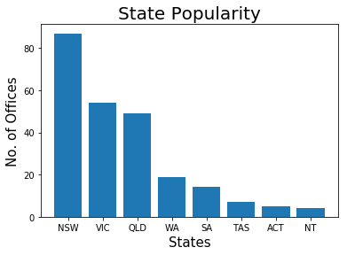

```python
# INSERT YOUR CODE HERE
'''
5. Plot a bar chart for state_popularity sorted in descending order of values.
'''
#make descending list of state
descState = state_popularity.most_common()

#use first element of tuples in descState list
stateName = [x[0] for x in descState]
values = list(state_popularity.values())

#put values in descending order
values.sort(reverse=True)

# assigned to variable to stop output of function type/address printing
statePop = plt.bar(range(len(state_popularity)), values, tick_label = stateName)
plotTitle = plt.title('State Popularity', fontsize = 20)
x_axis_label = plt.xlabel('States', fontsize = 15)
y_axis_label = plt.ylabel('No. of Offices', fontsize = 15)
```

## **Instruction 4**

We shall examine the opening hours of the medicare offices. The time is a string in the format: **'Hour:Minute:Second'**. If the time is not in the correct form, the opening duration of the office is **invalid**. Run the cell below:

```python
# print the opening time and closing time of the first medicare office.

print(data_dict['Open'][0])
print(data_dict['Close'][0])
```

```
8:30:00
16:30:00
```

**Your tasks**:

1. Define a function called `compute_opening_duration` that takes two strings: the opening time and the closing time as the inputs and return the opening duration in hours. If the opening time or the closing time are not in the correct form, the function returns -1. (**7 marks**)
2. Write your code to calculate an array called **opening_duration_list** that stores the opening duration of all medicare offices. Store the array as a numpy array. Print the first 10 entries in the array. (**3 mark**)
3. Construct a new array called **valid_opening_duration_list** to store only valid opening duration entries and then print out the number of elements in the array. (**3 marks**)
4. Print the min, max, median and construct a box-plot for variable **valid_opening_duration_list**. (**5 marks**)

[**Total mark: 18**]

```python
'''
1. Define a function called `compute_opening_duration` to calculate the duration of the opening time.
The function takes two strings: the opening time and the closing time as the inputs and return the opening duration in hours.
The opening time and the closing time are in the form 'Hour:Minute:Second'.
If the opening time or the closing time are not in the correct form, the function returns -1.

Example:
    opening time: '8:30:00', closing time: '16:00:00', return 7.5
    opening time: '9:00:00', closing time: '16:15:00', return 7.25
    opening time: '8:30:00', closing time: 'evening', return -1

Hint: you might want to use datetime package
'''
from datetime import timedelta

def compute_opening_duration(opening_time, closing_time):
    '''
    Input: two string: opening_time and closing_time
    Output: the opening duration in hours
    Return -1 if any time is in incorrect form.
    '''
    # INSERT YOUR CODE HERE

    # set date format
    datetimeFormat = '%H:%M:%S'

    #try-catch checks for correct format
    try:
        timedelta = datetime.strptime(closing_time, datetimeFormat) - datetime.strptime(opening_time, datetimeFormat)
        # get absolute value of time difference
        difference = abs(timedelta)
        # get total seconds and then change to hours
        total_hours = difference.total_seconds() / 3600.0
        return total_hours
    except ValueError:
        return("-1")
```

```python
# INSERT YOUR CODE HERE
"""
2. Write your code to calculate an array called **opening_duration_list**
    that stores the opening duration of all medicare offices.
Store the array as a numpy array.
Print the first 10 entries in the array.
"""
#create empty list to append values to
hours_list = []

#iterate over the first 10 rows
for i in range(len(data_dict['No.'])):
    openTime = (data_dict['Open'][i])
    closeTime = (data_dict['Close'][i])
    hours_list.append(compute_opening_duration(openTime, closeTime))

#index for SITE NAME
j = 0
#make numpy array from hours_list
opening_duration_list = np.array(hours_list)
for i in opening_duration_list[0:10]:
    print(str(data_dict['SITE NAME'][j]) + " is open for " +str(i)+ " hours")
    j += 1
```

```
Armadale (WA) is open for 8.0 hours
Armidale (NSW) is open for 8.5 hours
Newport is open for 6.5 hours
Townsville Jobseekers is open for 7.5 hours
Albany is open for 6.5 hours
Atherton is open for 6.5 hours
Alice Springs is open for 8.5 hours
Ayr is open for 6.5 hours
Ararat is open for 7.5 hours
Airport West is open for 6.5 hours
```

```python
# INSERT YOUR CODE HERE
"""
3. Construct a new array called **valid_opening_duration_list** to store only valid opening duration entries and
then print out the number of elements in the array.
"""
j = 0
count = 0
valid_opening_duration_list = []
for i in opening_duration_list:
    # check for values of '-1'
    if opening_duration_list[j] != '-1':
        valid_opening_duration_list.append(i)
        count += 1
    j += 1

print("There are " +str(count) + " locations with valid open hours")
```

```
There are 235 locations with valid open hours
```

```
Minimum hours open: 6.5
Maximum hours open: 9.0
Median hours open: 8.0
```

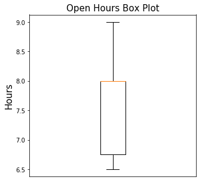

```python
# INSERT YOUR CODE HERE
"""
4. Print the min, max, median and construct a box-plot for variable **valid_opening_duration_list**
"""
minHours = min(valid_opening_duration_list)
maxHours = max(valid_opening_duration_list)
medianHours = median(valid_opening_duration_list)

print("Minimum hours open: " +str(minHours))
print("Maximum hours open: " +str(maxHours))
print("Median hours open: " +str(medianHours))

validHours = []
for i in valid_opening_duration_list:
    validHours.append(float(i))

# set plot size
fig, ax = plt.subplots(figsize=(5, 5))
boxPlot = ax.boxplot(validHours)
y_axis_Label = ax.set_ylabel('Hours', fontsize = 15)
plot_title = ax.set_title('Open Hours Box Plot', fontsize = 15)
# remove tick mark on x axis
x_axis_tick = plt.xticks([])
```

## **Instruction 5**

Continue from the previous steps, **your tasks are:**

1. Write your code to find and print all the invalid entry indices. An entry is invalid when its opening duration is invalid. (**5 marks**).
2. Write your code to filter out all invalid entries and store your data into a new variable **data_dict_cleaned** and print out the number of data records after being cleaned. (**5 marks**)

[**Total mark: 10**]

```python
# INSERT YOUR CODE HERE
"""
1. Write your code to find and print all the invalid entry indices.
 You might want to use np.where function.
"""

invalid_entries = np.where(opening_duration_list == '-1')

# a list to make the output neat
invalid_indicies = np.asarray(invalid_entries)

print("Invalid entries at indices: " +str(invalid_indicies))
```

```
Invalid entries at indices: [[ 15  35 127 220]]
```

```python
# INSERT YOUR CODE HERE
"""
2. Write your code to filter out all invalid entries
and store your data into a new variable data_dict_cleaned
and print out the number of data records after being cleaned.
"""
data_dict_cleaned = []

for i in np.nditer(opening_duration_list):
    if (i != '-1'):
        data_dict_cleaned.append(i)

print("There are " +str(len(data_dict_cleaned))+ " valid data records")
```

```
There are 235 valid data records
```

## **Instruction 6**

The following code segment is designed to examine data from **ADDRESS** column.

We say that an address is **valid** if it contains the number and the name of the street, which are separated by spaces. The formats for a valid street name is **"stNumber stName"** or **"stNumber1-stNumber2 stName"**, where **stNumber**, **stNumber1** and **stNumber2** are positive numbers and **stName** is any non-empty string. For example, **20 St Kilda Road** and **100-104 Elliott Avenue** are valid addresses while **St Kilda Road** and **0 Elliott Avenue** are invalid addresses.

**Your tasks**:

1. Define a function called `valid_address` that takes a string `address` and returns `True` if `address` is valid and `False` otherwise. (**7 marks**)
2. Write your code to **further** filter out all entries with invalid addresses, and store your cleaned data into the new variable named *data_dict_cleaned2* and print out the number of data records after being cleaned. (**5 marks**)

**Note:**

1. All street numbers if exist in an address are integers. There is at most a hyphen in an address to connect two street numbers.
2. In reality, an address can be "Shop 3, 10 St Kilda Road". However, for simplicity, we only consider the valid address contains street numbers and a street name.

[**Total mark: 12**]

```python
# INSERT YOUR CODE HERE
'''
1. Define a function called valid_address that takes a string address and
returns True if address is valid and False otherwise.
'''
# regular expression to see if first character is an integer between 1 and 9
regex = r"^[1-9]+"
address_list= data_dict['ADDRESS']

def valid_address(address):
    for i in range(len(address)):
        if re.search(regex, address[i]):
            return(True)
        else:
            return(False)
```

```python
# INSERT YOUR CODE HERE
"""
2. Write your code to further filter out all entries with invalid addresses, and store your cleaned data
    into the new variable named data_dict_cleaned2 and print out the number of data records
    after being cleaned.
"""
data_dict_cleaned2 = []
for i in range(len(address_list)):
    if valid_address(address_list[i]) == True:
        data_dict_cleaned2.append(address_list[i])

print("There are " +str(len(data_dict_cleaned2))+ " valid data records")
```

```
There are 200 valid data records
```